# Week 5-6 Data Preprocessing HW

B12801002 公衛三 張元貞

2025-10-19

### 1. Introduction & Setup

- Briefly describe the purpose of this analysis (NHANES data, 2021–2023).
- Load all required packages and datasets.
- Ensure reproducibility by including all code chunks in order.

This analysis utilizes data from the 2021-2023 National Health and Nutrition Examination Survey (NHANES) to perform a comprehensive data cleaning and exploratory analysis workflow. In the first phase (Week 5), the primary focus was on Body Mass Index (BMI) and Systolic Blood Pressure (SBP). We compared the data distribution and missingness rates of these variables before and after a rigorous outlier cleaning process, visualizing the results using boxplots. The second phase (Week 6) shifted to exploring sociodemographic disparities by analyzing the distribution of BMI across different race/ethnicity and educational attainment groups. Additionally, we conducted a detailed distribution analysis of repeated blood pressure (BP) measurements to examine trial-to-trial variability.

### 2. Week 5 Components (BMI & SBP Cleaning)

Q1. Among adults aged ≥20 years in the 2021–2023 NHANES, observe the association between BMI and mean systolic blood pressure (SBP) and does the association vary between sex ? Steps for answering the question:

I. Install & load the related packages

```r
# 1) Packages and folders ---------------------------------------------------
pkgs <- c("tidyverse","haven","janitor","stringr","scales","skimr","naniar") # tidyverse: metapackage (including dplyr, tidyr, ggplot2), haven: read SAS/XPT files
to_install <- setdiff(pkgs, rownames(installed.packages()))
if (length(to_install)) install.packages(to_install)
invisible(lapply(pkgs, library, character.only = TRUE))
dir.create("outputs", showWarnings = FALSE) # where plots will be saved
data_dir <- "C:\\Users\\USER\\Desktop\\健康大數據"                      # folder containing .XPT files

getwd()  # check working directory
```

```
## [1] "C:/Users/USER/Desktop/健康大數據/Big-Data-Hw"
```

```r
# 2) Load raw data ----------------------------------------------------------
demo <- read_xpt(file.path(data_dir,"DEMO_L.XPT")) %>% clean_names()  # %>% is one of the most important operators in the tidyverse, it pronounce as“and then”
bpx  <- read_xpt(file.path(data_dir,"BPXO_L.XPT")) %>% clean_names()  # clean_names() from janitor package: make column names consistent (lowercase, no spaces or special characters)
bmx  <- read_xpt(file.path(data_dir,"BMX_L.XPT"))  %>% clean_names()
```

2. Read the raw data files and quick view to the datasets

```r
# quick overviews (on-screen)
skimr::skim(demo); skimr::skim(bpx); skimr::skim(bmx)
```

Data summary

| Name | demo |
| --- | --- |
| Number of rows | 11933 |
| Number of columns | 27 |
| _______________________ |  |
| Column type frequency: |  |
| numeric | 27 |
| ________________________ |  |
| Group variables | None |

**Variable type: numeric**

Data summary

| skim_variable | n_missing | complete_rate | mean | sd | p0 | p25 | p50 | p75 | p100 | hist |
| --- | --- | --- | --- | --- | --- | --- | --- | --- | --- | --- |
| seqn | 0 | 1.00 | 136344.00 | 3444.90 | 130378.00 | 133361.00 | 136344.00 | 139327.00 | 142310.0 | ▇▇▇▇▇ |
| sddsrvyr | 0 | 1.00 | 12.00 | 0.00 | 12.00 | 12.00 | 12.00 | 12.00 | 12.0 | ▁▁▇▁▁ |
| ridstatr | 0 | 1.00 | 1.74 | 0.44 | 1.00 | 1.00 | 2.00 | 2.00 | 2.0 | ▃▁▁▁▇ |
| riagendr | 0 | 1.00 | 1.53 | 0.50 | 1.00 | 1.00 | 2.00 | 2.00 | 2.0 | ▇▁▁▁▇ |
| ridageyr | 0 | 1.00 | 38.32 | 25.60 | 0.00 | 13.00 | 37.00 | 62.00 | 80.0 | ▇▃▃▅▆ |
| ridagemn | 11556 | 0.03 | 11.63 | 6.81 | 0.00 | 6.00 | 11.00 | 17.00 | 24.0 | ▆▇▇▆▆ |
| ridreth1 | 0 | 1.00 | 3.10 | 1.08 | 1.00 | 3.00 | 3.00 | 4.00 | 5.0 | ▂▂▇▂▂ |
| ridreth3 | 0 | 1.00 | 3.32 | 1.52 | 1.00 | 3.00 | 3.00 | 4.00 | 7.0 | ▃▇▂▁▂ |
| ridexmon | 3073 | 0.74 | 1.52 | 0.50 | 1.00 | 1.00 | 2.00 | 2.00 | 2.0 | ▇▁▁▁▇ |
| ridexagm | 9146 | 0.23 | 121.91 | 67.16 | 0.00 | 66.00 | 122.00 | 179.50 | 239.0 | ▆▇▇▇▇ |
| dmqmiliz | 3632 | 0.70 | 1.92 | 0.28 | 1.00 | 2.00 | 2.00 | 2.00 | 7.0 | ▇▁▁▁▁ |
| dmdborn4 | 19 | 1.00 | 1.16 | 0.36 | 1.00 | 1.00 | 1.00 | 1.00 | 2.0 | ▇▁▁▁▂ |
| dmdyrusr | 10058 | 0.16 | 7.33 | 15.83 | 1.00 | 3.00 | 6.00 | 6.00 | 99.0 | ▇▁▁▁▁ |
| dmdeduc2 | 4139 | 0.65 | 3.80 | 1.15 | 1.00 | 3.00 | 4.00 | 5.00 | 9.0 | ▂▇▅▁▁ |
| dmdmartz | 4141 | 0.65 | 1.78 | 3.10 | 1.00 | 1.00 | 1.00 | 2.00 | 99.0 | ▇▁▁▁▁ |
| ridexprg | 10430 | 0.13 | 2.24 | 0.49 | 1.00 | 2.00 | 2.00 | 3.00 | 3.0 | ▁▁▇▁▃ |
| dmdhhsiz | 0 | 1.00 | 3.24 | 1.70 | 1.00 | 2.00 | 3.00 | 4.00 | 7.0 | ▇▃▃▂▂ |
| dmdhrgnd | 7818 | 0.34 | 1.56 | 0.50 | 1.00 | 1.00 | 2.00 | 2.00 | 2.0 | ▆▁▁▁▇ |
| dmdhragz | 7809 | 0.35 | 2.54 | 0.64 | 1.00 | 2.00 | 2.00 | 3.00 | 4.0 | ▁▇▁▇▁ |
| dmdhredz | 8187 | 0.31 | 2.17 | 0.66 | 1.00 | 2.00 | 2.00 | 3.00 | 3.0 | ▂▁▇▁▅ |
| dmdhrmaz | 7913 | 0.34 | 1.38 | 0.68 | 1.00 | 1.00 | 1.00 | 2.00 | 3.0 | ▇▁▂▁▁ |
| dmdhsedz | 9806 | 0.18 | 2.28 | 0.69 | 1.00 | 2.00 | 2.00 | 3.00 | 3.0 | ▂▁▇▁▇ |
| wtint2yr | 0 | 1.00 | 27404.14 | 19449.16 | 4584.46 | 14331.75 | 21670.19 | 33831.33 | 170968.3 | ▇▂▁▁▁ |
| wtmec2yr | 0 | 1.00 | 27404.14 | 27962.96 | 0.00 | 0.00 | 21717.85 | 38341.15 | 227108.3 | ▇▂▁▁▁ |
| sdmvstra | 0 | 1.00 | 179.92 | 4.31 | 173.00 | 176.00 | 180.00 | 184.00 | 187.0 | ▇▇▇▇▇ |
| sdmvpsu | 0 | 1.00 | 1.49 | 0.50 | 1.00 | 1.00 | 1.00 | 2.00 | 2.0 | ▇▁▁▁▇ |
| indfmpir | 2041 | 0.83 | 2.71 | 1.67 | 0.00 | 1.18 | 2.50 | 4.50 | 5.0 | ▅▆▅▃▇ |

| Name | bpx |
| --- | --- |
| Number of rows | 7801 |
| Number of columns | 12 |
| _______________________ |  |
| Column type frequency: |  |
| character | 1 |
| numeric | 11 |
| ________________________ |  |
| Group variables | None |

**Variable type: character**

| skim_variable | n_missing | complete_rate | min | max | empty | n_unique | whitespace |
| --- | --- | --- | --- | --- | --- | --- | --- |
| bpaoarm | 0 | 1 | 0 | 1 | 147 | 3 | 0 |

**Variable type: numeric**

Data summary

| skim_variable | n_missing | complete_rate | mean | sd | p0 | p25 | p50 | p75 | p100 | hist |
| --- | --- | --- | --- | --- | --- | --- | --- | --- | --- | --- |
| seqn | 0 | 1.00 | 136349.49 | 3449.49 | 130378 | 133335 | 136382 | 139325 | 142310 | ▇▇▇▇▇ |
| bpaocsz | 190 | 0.98 | 3.52 | 0.67 | 2 | 3 | 4 | 4 | 5 | ▁▇▁▇▁ |
| bpxosy1 | 284 | 0.96 | 119.29 | 18.56 | 61 | 106 | 117 | 130 | 232 | ▁▇▂▁▁ |
| bpxodi1 | 284 | 0.96 | 72.75 | 11.90 | 33 | 64 | 72 | 80 | 142 | ▁▇▅▁▁ |
| bpxosy2 | 296 | 0.96 | 119.08 | 18.57 | 59 | 106 | 116 | 129 | 233 | ▁▇▃▁▁ |
| bpxodi2 | 296 | 0.96 | 72.09 | 11.85 | 32 | 64 | 71 | 79 | 139 | ▁▇▅▁▁ |
| bpxosy3 | 321 | 0.96 | 118.92 | 18.50 | 50 | 106 | 116 | 129 | 232 | ▁▇▅▁▁ |
| bpxodi3 | 321 | 0.96 | 71.81 | 11.77 | 24 | 64 | 71 | 79 | 136 | ▁▆▇▁▁ |
| bpxopls1 | 284 | 0.96 | 72.34 | 12.72 | 35 | 63 | 71 | 80 | 158 | ▂▇▂▁▁ |
| bpxopls2 | 296 | 0.96 | 73.09 | 12.78 | 32 | 64 | 72 | 81 | 141 | ▁▇▅▁▁ |
| bpxopls3 | 321 | 0.96 | 73.69 | 12.89 | 31 | 65 | 73 | 82 | 154 | ▁▇▃▁▁ |

| Name | bmx |
| --- | --- |
| Number of rows | 8860 |
| Number of columns | 22 |
| _______________________ |  |
| Column type frequency: |  |
| numeric | 22 |
| ________________________ |  |
| Group variables | None |

**Variable type: numeric**

| skim_variable | n_missing | complete_rate | mean | sd | p0 | p25 | p50 | p75 | p100 | hist |
| --- | --- | --- | --- | --- | --- | --- | --- | --- | --- | --- |
| seqn | 0 | 1.00 | 136345.83 | 3453.78 | 130378.0 | 133319.75 | 136377.5 | 139336.2 | 142310.0 | ▇▇▇▇▇ |
| bmdstats | 0 | 1.00 | 1.13 | 0.50 | 1.0 | 1.00 | 1.0 | 1.0 | 4.0 | ▇▁▁▁▁ |
| bmxwt | 106 | 0.99 | 70.55 | 30.39 | 2.7 | 54.20 | 71.7 | 89.1 | 248.2 | ▃▇▂▁▁ |
| bmiwt | 8515 | 0.04 | 2.88 | 0.62 | 1.0 | 3.00 | 3.0 | 3.0 | 4.0 | ▁▁▁▇▁ |
| bmxrecum | 8406 | 0.05 | 84.33 | 14.06 | 48.5 | 73.48 | 84.7 | 96.1 | 118.8 | ▂▆▇▇▂ |
| bmirecum | 8842 | 0.00 | 1.00 | 0.00 | 1.0 | 1.00 | 1.0 | 1.0 | 1.0 | ▁▁▇▁▁ |
| bmxhead | 8790 | 0.01 | 41.93 | 2.80 | 34.4 | 40.20 | 42.4 | 44.0 | 46.5 | ▁▃▅▇▆ |
| bmihead | 8860 | 0.00 | NaN | NA | NA | NA | NA | NA | NA |  |
| bmxht | 361 | 0.96 | 159.66 | 19.86 | 79.1 | 154.40 | 163.6 | 172.1 | 200.7 | ▁▁▂▇▂ |
| bmiht | 8726 | 0.02 | 2.31 | 0.95 | 1.0 | 1.00 | 3.0 | 3.0 | 3.0 | ▅▁▁▁▇ |
| bmxbmi | 389 | 0.96 | 27.25 | 8.14 | 11.1 | 21.60 | 26.4 | 31.7 | 74.8 | ▆▇▂▁▁ |
| bmdbmic | 6368 | 0.28 | 2.56 | 0.88 | 1.0 | 2.00 | 2.0 | 3.0 | 4.0 | ▁▇▁▂▃ |
| bmxleg | 1525 | 0.83 | 38.13 | 3.86 | 24.9 | 35.50 | 38.1 | 40.8 | 51.6 | ▁▃▇▃▁ |
| bmileg | 8464 | 0.04 | 1.00 | 0.00 | 1.0 | 1.00 | 1.0 | 1.0 | 1.0 | ▁▁▇▁▁ |
| bmxarml | 292 | 0.97 | 35.11 | 6.18 | 10.0 | 33.60 | 36.5 | 39.0 | 49.2 | ▁▁▂▇▁ |
| bmiarml | 8660 | 0.02 | 1.00 | 0.00 | 1.0 | 1.00 | 1.0 | 1.0 | 1.0 | ▁▁▇▁▁ |
| bmxarmc | 298 | 0.97 | 30.56 | 7.37 | 12.0 | 26.40 | 31.2 | 35.4 | 63.3 | ▃▇▇▁▁ |
| bmiarmc | 8655 | 0.02 | 1.00 | 0.00 | 1.0 | 1.00 | 1.0 | 1.0 | 1.0 | ▁▁▇▁▁ |
| bmxwaist | 670 | 0.92 | 92.12 | 22.05 | 39.8 | 77.50 | 92.7 | 107.0 | 187.0 | ▃▇▆▁▁ |
| bmiwaist | 8513 | 0.04 | 1.00 | 0.00 | 1.0 | 1.00 | 1.0 | 1.0 | 1.0 | ▁▁▇▁▁ |
| bmxhip | 2084 | 0.76 | 106.26 | 14.66 | 69.9 | 96.40 | 103.7 | 113.5 | 187.1 | ▂▇▂▁▁ |
| bmihip | 8499 | 0.04 | 1.00 | 0.00 | 1.0 | 1.00 | 1.0 | 1.0 | 1.0 | ▁▁▇▁▁ |

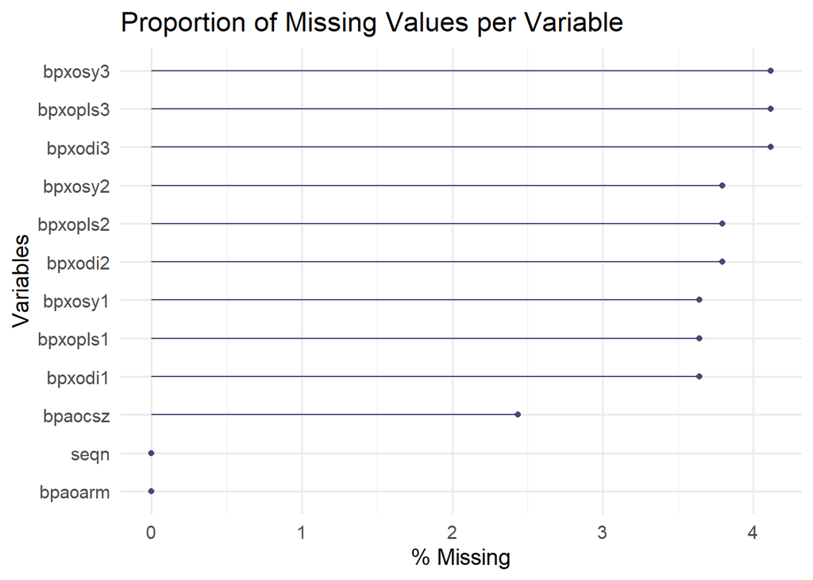

```r
gg_miss_var(bpx, show_pct = TRUE) +
  theme_minimal(base_size = 14) +
  labs(title = "Proportion of Missing Values per Variable")
```

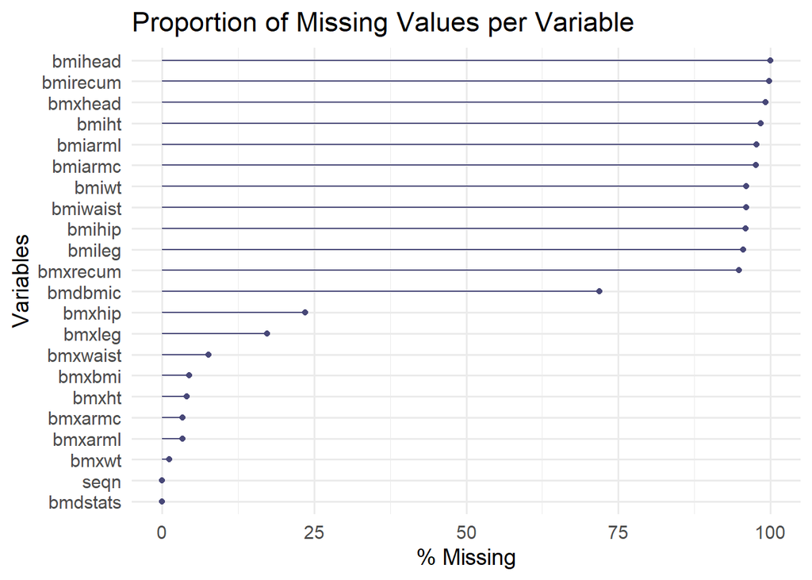

```r
gg_miss_var(bmx, show_pct = TRUE) +
  theme_minimal(base_size = 14) +
  labs(title = "Proportion of Missing Values per Variable")
```

3. Find out the targeted column from datasets for this question and define them

```r
sbp_cols <- names(bpx)[stringr::str_detect(names(bpx), "^bpxo?sy[1-3]$")]  # names() returns the column names of a data frame.(character vector)
dbp_cols <- names(bpx)[stringr::str_detect(names(bpx), "^bpxo?di[1-3]$")]  # str_detect(x, pattern) returns TRUE or FALSE for each element of x, depending on whether it matches the regex pattern.
```

4. Build the original variables (including checking the coding correctness) and dataset for constructing plots before cleaning

```r
bmi_raw <- bmx %>%
  transmute(seqn, bmi_raw = bmxbmi)

sbp_raw <- bpx %>%
  transmute(seqn, sbp_raw = rowMeans(select(., all_of(sbp_cols)), na.rm = TRUE))
dbp_raw <- bpx %>%
  transmute(seqn, dbp_raw = rowMeans(select(., all_of(dbp_cols)), na.rm=TRUE))

table(demo$riagendr) # $ means "grab" the column from the data frame
```

```
##
##    1    2
## 5575 6358
```

```r
# 清理人口統計數據並創建 sex 因子變數
demo_sex <- demo %>%
  filter(is.na(riagendr) | riagendr %in% c(1, 2)) %>%
  transmute(
    seqn,
    age = ridageyr,
    sex = factor(riagendr, levels = c(1, 2), labels = c("Male", "Female"))
  )

## 數據整合與最終清理
dat_raw <- demo_sex %>%
  left_join(sbp_raw, by = "seqn") %>%  # 合併 SBP
  left_join(dbp_raw, by = "seqn") %>%  # 合併 DBP
  left_join(bmi_raw, by = "seqn") %>%  # 合併 BMI
  filter(age >= 20) %>% # 限制年齡 >= 20 歲
  mutate(
    # 將 rowMeans 產生的 NaN 轉換為標準 NA
    sbp_raw = ifelse(is.nan(sbp_raw), NA_real_, sbp_raw),
    dbp_raw = ifelse(is.nan(dbp_raw), NA_real_, dbp_raw),
    bmi_raw = ifelse(is.nan(bmi_raw), NA_real_, bmi_raw)
  )
```

V. Draw the raw data boxplots of BMI & mean SBP separately

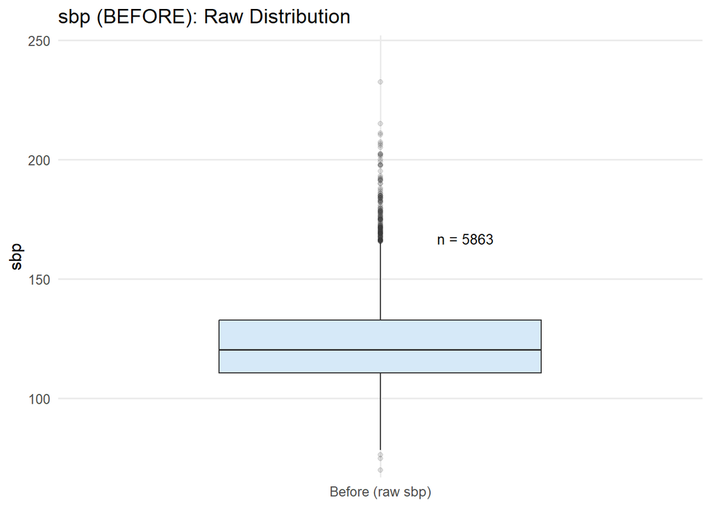

```r
# ---- sbp boxplot (BEFORE) ----
sbp_before_df <- dat_raw %>% transmute(stage = "Before (raw sbp)", value = sbp_raw)
x_sbp <- sbp_before_df$value
qs_sbp <- quantile(x_sbp, c(.25,.75), na.rm = TRUE)  # na.rm=TRUE to ignore missing values
iqr_sbp <- qs_sbp[2]-qs_sbp[1]
upper_whisker <- min(max(x_sbp, na.rm = TRUE), qs_sbp[2] + 1.5*iqr_sbp)  # upper whisker position, Q3 + 1.5×IQR, capped by max value.
sbp_before_label_y <- upper_whisker + 0.05*iqr_sbp
sbp_before_N <- sum(!is.na(x_sbp))   # count of non-missing values, !is.na() means "not NA"

p_sbp_before <- ggplot(sbp_before_df, aes(stage, value, fill = stage)) +
  geom_boxplot(width = 0.6, outlier.alpha = 0.15, fatten = 1.2) +
  geom_text(data = tibble(stage="Before (raw sbp)", y=sbp_before_label_y, N=sbp_before_N),
            aes(stage, y, label=paste0("n = ", N)), hjust = -1, size = 3.5, inherit.aes = FALSE) +
  scale_fill_manual(values = c("Before (raw sbp)" = "#D6E9F8")) +
  labs(title = "sbp (BEFORE): Raw Distribution", x = NULL, y = "sbp") +
  scale_y_continuous(expand = expansion(mult = c(0.02, 0.12))) +
  theme_minimal(base_size = 12) + theme(legend.position = "none", panel.grid.minor = element_blank())
ggsave("outputs/q1_box_sbp_before.png", p_sbp_before, bg = "white")
print(p_sbp_before)
```

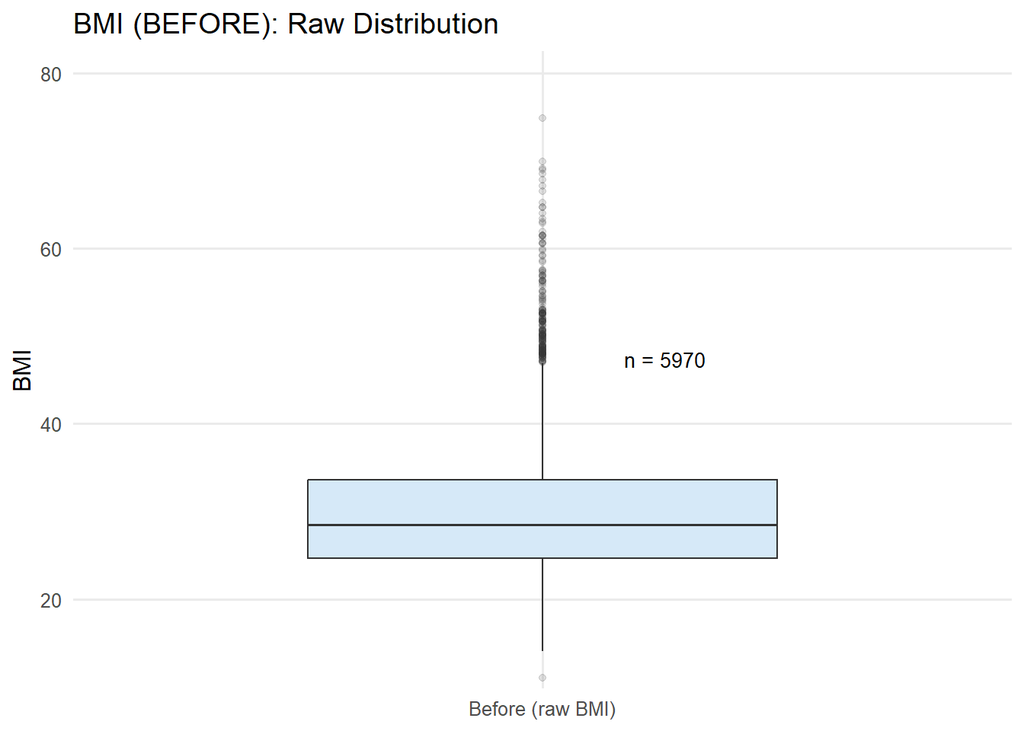

```r
# ---- bmi boxplot (BEFORE) ----
bmi_before_df <- dat_raw %>% transmute(stage = "Before (raw BMI)", value = bmi_raw)
x_bmi <- bmi_before_df$value
qs_bmi <- quantile(x_bmi, c(.25,.75), na.rm = TRUE)  # na.rm=TRUE to ignore missing values
iqr_bmi <- qs_bmi[2]-qs_bmi[1]
upper_whisker <- min(max(x_bmi, na.rm = TRUE), qs_bmi[2] + 1.5*iqr_bmi)  # upper whisker position, Q3 + 1.5×IQR, capped by max value.
bmi_before_label_y <- upper_whisker + 0.05*iqr_bmi
bmi_before_N <- sum(!is.na(x_bmi))   # count of non-missing values, !is.na() means "not NA"

p_bmi_before <- ggplot(bmi_before_df, aes(stage, value, fill = stage)) +
  geom_boxplot(width = 0.6, outlier.alpha = 0.15, fatten = 1.2) +
  geom_text(data = tibble(stage="Before (raw BMI)", y=bmi_before_label_y, N=bmi_before_N),
            aes(stage, y, label=paste0("n = ", N)), hjust = -1, size = 3.5, inherit.aes = FALSE) +
  scale_fill_manual(values = c("Before (raw BMI)" = "#D6E9F8")) +
  labs(title = "BMI (BEFORE): Raw Distribution", x = NULL, y = "BMI") +
  scale_y_continuous(expand = expansion(mult = c(0.02, 0.12))) +
  theme_minimal(base_size = 12) + theme(legend.position = "none", panel.grid.minor = element_blank())
ggsave("outputs/q1_box_bmi_before.png", p_bmi_before, bg = "white")
print(p_bmi_before)
```

6. Outlier cleaning (Rule = physiologic bounds + IQR fences + MAD z-score)

```r
sbp_LO <- 70; sbp_HI <- 260
sbp_clean <- sbp_raw %>%
  mutate(
    q1_sbp = quantile(sbp_raw, 0.25, na.rm=TRUE),
    q3_sbp = quantile(sbp_raw, 0.75, na.rm=TRUE),
    iqr_sbp = q3_sbp - q1_sbp,
    lo_iqr_sbp = q1_sbp - 1.5*iqr_sbp,
    hi_iqr_sbp = q3_sbp + 1.5*iqr_sbp,
    med_sbp = median(sbp_raw, na.rm=TRUE),
    madv_sbp = mad(sbp_raw, na.rm=TRUE),
    z = ifelse(madv_sbp > 0, (sbp_raw - med_sbp)/(madv_sbp*1.4826), 0),  # 1.4826 to make it comparable to SD if normal
    flag = (sbp_raw < sbp_LO | sbp_raw > sbp_HI) | (sbp_raw < lo_iqr_sbp | sbp_raw > hi_iqr_sbp) | (abs(z) > 3.5),  # flag outliers
    sbp_raw_clean = ifelse(flag, NA_real_, sbp_raw)
  ) %>% select(seqn, sbp_raw_clean)



BMI_LO <- 10; BMI_HI <- 80
bmi_clean <- bmx %>%
  transmute(seqn, bmxbmi) %>%
  mutate(
    q1_bmi = quantile(bmxbmi, 0.25, na.rm=TRUE),
    q3_bmi = quantile(bmxbmi, 0.75, na.rm=TRUE),
    iqr_bmi = q3_bmi - q1_bmi,
    lo_iqr_bmi = q1_bmi - 1.5*iqr_bmi,
    hi_iqr_bmi = q3_bmi + 1.5*iqr_bmi,
    med_bmi = median(bmxbmi, na.rm=TRUE),
    madv_bmi = mad(bmxbmi, na.rm=TRUE),
    z = ifelse(madv_bmi > 0, (bmxbmi - med_bmi)/(madv_bmi*1.4826), 0),  # 1.4826 to make it comparable to SD if normal
    flag = (bmxbmi < BMI_LO | bmxbmi > BMI_HI) | (bmxbmi < lo_iqr_bmi | bmxbmi > hi_iqr_bmi) | (abs(z) > 3.5),  # flag outliers
    bmxbmi_clean = ifelse(flag, NA_real_, bmxbmi)
  ) %>% select(seqn, bmxbmi_clean)
```

7. Build AFTER cleaning datasets

```r
dat_clean <- demo_sex %>%
  left_join(sbp_clean, by="seqn") %>%
  left_join(bmi_clean, by="seqn") %>%
  filter(age >= 20) %>%
  mutate(
    sbp_raw_clean = ifelse(is.nan(sbp_raw_clean), NA_real_, sbp_raw_clean),  # normalize NaN to names()
    bmxbmi_clean = ifelse(is.nan(bmxbmi_clean), NA_real_, bmxbmi_clean)  # normalize NaN to NA
  )
```

8. Draw the cleaned data boxplots of BMI & mean SBP

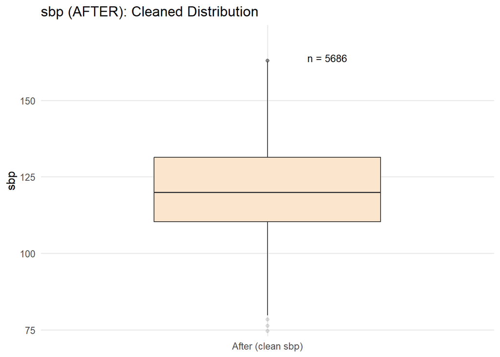

```r
# ---- SBP boxplot (AFTER) ----
sbp_after_df <- dat_clean %>% transmute(stage = "After (clean sbp)", value = sbp_raw_clean)
x_sbp <- sbp_after_df$value
qs_sbp <- quantile(x_sbp, c(.25,.75), na.rm = TRUE);
iqr_sbp <- qs_sbp[2]-qs_sbp[1]
upper_whisker_sbp <- min(max(x_sbp, na.rm = TRUE), qs_sbp[2] + 1.5*iqr_sbp)
sbp_after_label_y <- upper_whisker_sbp + 0.05*iqr_sbp
sbp_after_N <- sum(!is.na(x_sbp))

p_sbp_after <- ggplot(sbp_after_df, aes(stage, value, fill = stage)) +
  geom_boxplot(width = 0.6, outlier.alpha = 0.15, fatten = 1.2) +
  geom_text(data = tibble(stage="After (clean sbp)", y=sbp_after_label_y, N=sbp_after_N),
            aes(stage, y, label=paste0("n = ", N)), hjust = -1, size = 3.5, inherit.aes = FALSE) +
  scale_fill_manual(values = c("After (clean sbp)" = "#FCE5CD")) +
  labs(title = "sbp (AFTER): Cleaned Distribution", x = NULL, y = "sbp") +
  scale_y_continuous(expand = expansion(mult = c(0.02, 0.12))) +
  theme_minimal(base_size = 12) + theme(legend.position = "none", panel.grid.minor = element_blank())
ggsave("outputs/q1_box_sbp_after.png", p_sbp_after, bg = "white")
print(p_sbp_after)
```

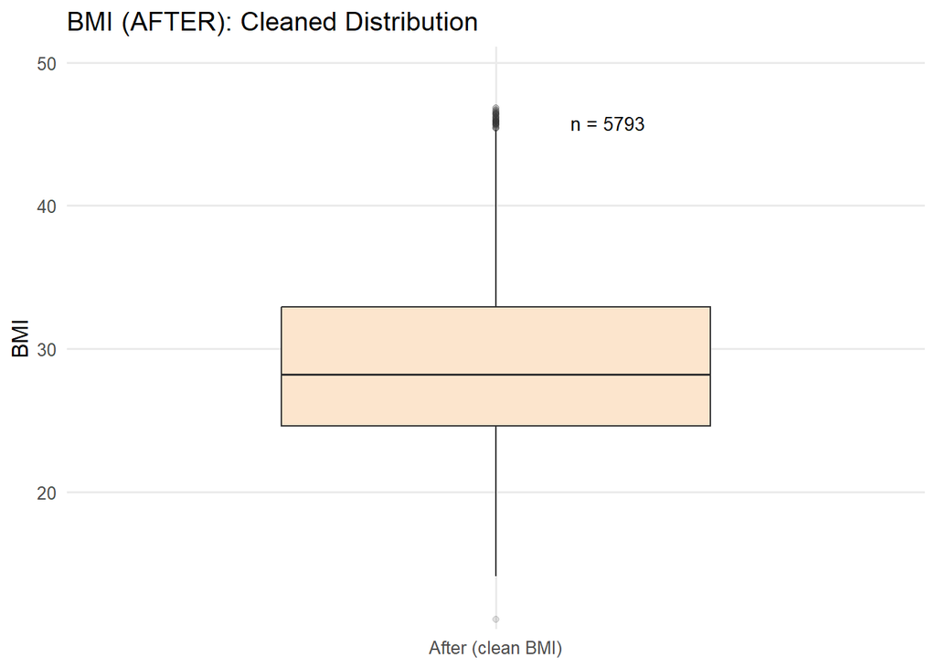

```r
# ---- BMI boxplot (AFTER) ----
bmi_after_df <- dat_clean %>% transmute(stage = "After (clean BMI)", value = bmxbmi_clean)
x_bmi <- bmi_after_df$value
qs_bmi <- quantile(x_bmi, c(.25,.75), na.rm = TRUE);
iqr_bmi <- qs_bmi[2]-qs_bmi[1]
upper_whisker_bmi <- min(max(x_bmi, na.rm = TRUE), qs_bmi[2] + 1.5*iqr_bmi)
bmi_after_label_y <- upper_whisker_bmi + 0.05*iqr_bmi
bmi_after_N <- sum(!is.na(x_bmi))

p_bmi_after <- ggplot(bmi_after_df, aes(stage, value, fill = stage)) +
  geom_boxplot(width = 0.6, outlier.alpha = 0.15, fatten = 1.2) +
  geom_text(data = tibble(stage="After (clean BMI)", y=bmi_after_label_y, N=bmi_after_N),
            aes(stage, y, label=paste0("n = ", N)), hjust = -1, size = 3.5, inherit.aes = FALSE) +
  scale_fill_manual(values = c("After (clean BMI)" = "#FCE5CD")) +
  labs(title = "BMI (AFTER): Cleaned Distribution", x = NULL, y = "BMI") +
  scale_y_continuous(expand = expansion(mult = c(0.02, 0.12))) +
  theme_minimal(base_size = 12) + theme(legend.position = "none", panel.grid.minor = element_blank())
ggsave("outputs/q1_box_bmi_after.png", p_bmi_after, bg = "white")
print(p_bmi_after)
```

9. Check the NA count change before and after cleaning (by bar plots)

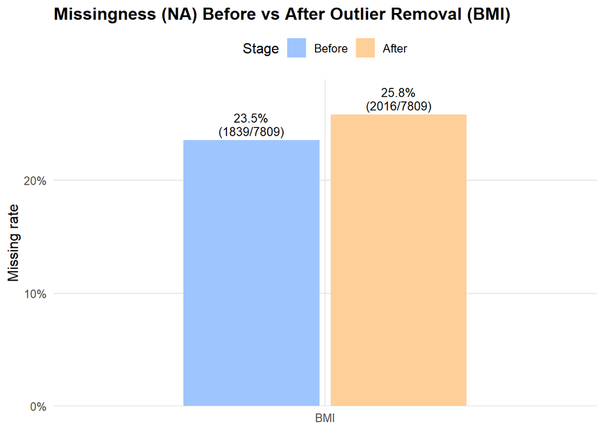

```r
miss_before_bmi <- tibble(
  stage     = "Before",
  variable  = "BMI",
  n_missing = sum(is.na(dat_raw$bmi_raw)),
  n_total   = nrow(dat_raw)
) %>% mutate(p_missing = n_missing / n_total)

miss_after_bmi <- tibble(
  stage     = "After",
  variable  = "BMI",
  n_missing = sum(is.na(dat_clean$bmxbmi_clean)),
  n_total   = nrow(dat_clean)
) %>% mutate(p_missing = n_missing / n_total)

miss_long_bmi <- bind_rows(miss_before_bmi, miss_after_bmi) %>%
  mutate(stage = factor(stage, levels = c("Before","After")),  # ensure order in plot legend
         variable = factor(variable, levels = "BMI"))          # ensure order in x-axis

p_na_bar_1 <- ggplot(miss_long_bmi, aes(variable, p_missing, fill = stage)) +
  geom_col(width=0.6, position="dodge") +                                                  # dodge to separate bars
  geom_text(aes(label = paste0(scales::percent(p_missing, 0.1),
                               "\n(", n_missing, "/", n_total, ")")),                      # label on top of bars
            vjust=-0.2, size=3.5) +
  scale_y_continuous(labels=scales::percent) +
  labs(title = "SBP Missingness Before vs After Cleaning", x=NULL, y="Missing rate") +
  theme_minimal(base_size=12) + theme(legend.position="top")

pos <- position_dodge(width = 0.65) # to align text labels with bars when using dodge

p_na_bar_2 <- ggplot(miss_long_bmi, aes(variable, p_missing, fill = stage)) +
  geom_col(width = 0.6, position = pos) +
  geom_text(aes(label = paste0(scales::percent(p_missing, 0.1),
                               "\n(", n_missing, "/", n_total, ")")),
            position = pos, vjust = -0.2, size = 3.5, lineheight = 0.95) +
  scale_y_continuous(labels = scales::percent, expand = expansion(mult = c(0, 0.12))) +
  scale_fill_manual(values = c("Before" = "#9EC5FE", "After" = "#FFCF99")) +
  labs(title = "Missingness (NA) Before vs After Outlier Removal (BMI)",
       x = NULL, y = "Missing rate", fill = "Stage") +
  theme_minimal(base_size = 12) +
  theme(panel.grid.minor = element_blank(),
        plot.title = element_text(face = "bold"),
        legend.position = "top")

ggsave("outputs/q1_na_bmi_before_after.png", p_na_bar_2, bg = "white")
print(p_na_bar_2)
```

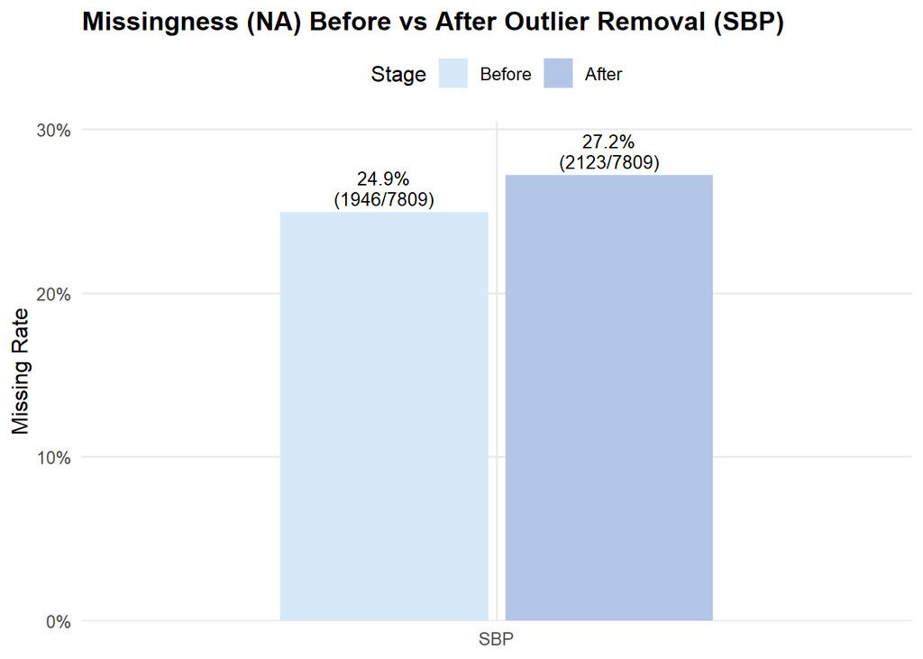

```r
miss_before_sbp <- tibble(
  stage     = "Before",
  variable  = "SBP",
  n_missing = sum(is.na(dat_raw$sbp_raw)),
  n_total   = nrow(dat_raw)
) %>% mutate(p_missing = n_missing / n_total)

miss_after_sbp <- tibble(
  stage     = "After",
  variable  = "SBP",
  n_missing = sum(is.na(dat_clean$sbp_raw_clean)),
  n_total   = nrow(dat_clean)
) %>% mutate(p_missing = n_missing / n_total)

miss_long_sbp <- bind_rows(miss_before_sbp, miss_after_sbp) %>%
  mutate(stage = factor(stage, levels = c("Before", "After")),
         variable = factor(variable, levels = "SBP"))

pos <- position_dodge(width = 0.65)
p_na_bar_sbp <- ggplot(miss_long_sbp, aes(variable, p_missing, fill = stage)) +
  geom_col(width = 0.6, position = pos) +
  geom_text(aes(label = paste0(scales::percent(p_missing, 0.1),
                               "\n(", n_missing, "/", n_total, ")")),
            position = pos, vjust = -0.2, size = 3.5, lineheight = 0.95) +
  scale_y_continuous(labels = scales::percent, expand = expansion(mult = c(0, 0.12))) +
  scale_fill_manual(values = c("Before" = "#D6E9F8", "After" = "#B4C6E7")) +
  labs(title = "Missingness (NA) Before vs After Outlier Removal (SBP)",
       x = NULL, y = "Missing Rate", fill = "Stage") +
  theme_minimal(base_size = 12) +
  theme(panel.grid.minor = element_blank(),
        plot.title = element_text(face = "bold"),
        legend.position = "top")

ggsave("outputs/q1_na_sbp_before_after.png", p_na_bar_sbp, bg = "white")
print(p_na_bar_sbp)
```

X. Scatter plot of cleaned BMI vs cleaned SBP by sex

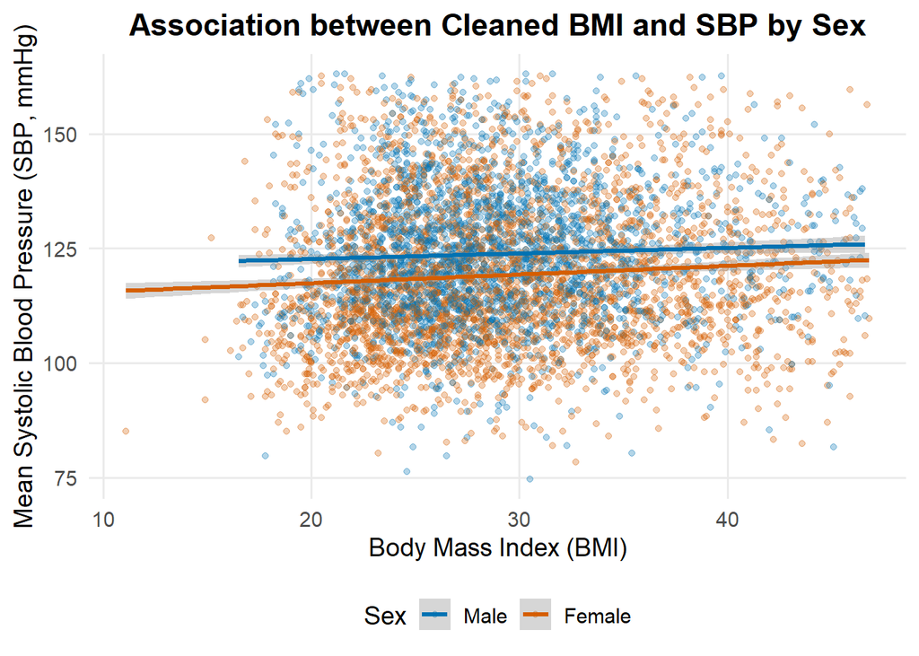

```r
p_scatter_bmi_sbp <- ggplot(dat_clean, aes(x = bmxbmi_clean, y = sbp_raw_clean, color = sex)) +

  # 1. 繪製散點圖 (geom_point)，設置 alpha 讓點重疊時能看出密度
  geom_point(alpha = 0.3, size = 1.5) +

  # 2. 添加性別分組的平滑/趨勢線 (geom_smooth)
  #    method="lm" 表示使用線性模型 (Linear Model) 來擬合趨勢
  geom_smooth(method = "lm", se = TRUE, linewidth = 1.2) +

  # 3. 設置圖表標籤和標題
  labs(
    title = "Association between Cleaned BMI and SBP by Sex",
    x = "Body Mass Index (BMI)",
    y = "Mean Systolic Blood Pressure (SBP, mmHg)",
    color = "Sex" # 圖例標題
  ) +

  scale_color_manual(values = c("Male" = "#0072B2", "Female" = "#D55E00")) + # 使用顏色友好的配色
  theme_minimal(base_size = 14) +
  theme(
    plot.title = element_text(face = "bold", hjust = 0.5), # 標題置中
    legend.position = "bottom",
    panel.grid.minor = element_blank()
  )

ggsave("outputs/q1_scatter_bmi_sbp_by_sex.png", p_scatter_bmi_sbp, bg = "white")
print(p_scatter_bmi_sbp)
```

Overall Trend: Both trend lines exhibit an upward slope, confirming the positive correlation between BMI and mean SBP regardless of sex.

Sex Differences: Although both trend lines show a positive correlation, the SBP trend line for males (blue) generally lies above the SBP trend line for females (red) across most BMI ranges. This suggests that, at the same BMI level, males tend to have a higher SBP.

### 3. Week 6 Components (EDU, Race, and BP Trials)

Q1. Among all the subjects in 2021-2023 NHANES dataset, observe the distribution of BMI in different races and education levels

I. What is the distribution of educational attainment (EDU) and ethnicity (Race) in your data?

```r
# 1) Check the original coding distribution
demo %>% count(dmdeduc2)
```

```
## # A tibble: 7 × 2
##   dmdeduc2     n
##      <dbl> <int>
## 1        1   373
## 2        2   666
## 3        3  1749
## 4        4  2370
## 5        5  2625
## 6        9    11
## 7       NA  4139
```

```r
demo %>% count(ridreth3)
```

```
## # A tibble: 6 × 2
##   ridreth3     n
##      <dbl> <int>
## 1        1  1117
## 2        2  1373
## 3        3  6217
## 4        4  1597
## 5        6   681
## 6        7   948
```

```r
# 2) Recode & relabel
dat_edu <- demo %>%
  transmute(
    seqn,
    age = ridageyr,
    EDU = case_when(                  # case_when() is like ifelse() but for multiple conditions
      dmdeduc2 %in% 1:5 ~ dmdeduc2,   # retain 1–5
      TRUE ~ NA_real_                 # 7/9 -> NA
    )
  ) %>%
  mutate(
    EDU = factor(EDU,                 # mutate() adds new variables or transforms existing ones
                 levels = 1:5,
                 labels = c("<9th grade", "9–11th grade", "High school/GED",
                            "Some college/AA", "College or above"))
  ) %>%
  left_join(dat_clean %>% select(seqn, bmxbmi_clean), by = "seqn") %>%
  drop_na(EDU, bmxbmi_clean)



dat_race <- demo %>%
  transmute(
    seqn,
    age = ridageyr,
    race = case_when(
      ridreth3 %in% 1:7 ~ ridreth3, # 保留 1–7 的有效編碼 (包括跳過的 5)
      TRUE ~ NA_real_              # 將其他編碼 (如缺失值 9) 設為 NA
    )
  ) %>%
  mutate(
    race = factor(race,
                  levels = 1:7,
                  labels = c("Mexican American",
                             "Other Hispanic",
                             "Non-Hispanic White",
                             "Non-Hispanic Black",
                             "UNUSED",                          # <<< 此處是編碼 5 的位置 ( unused )
                             "Non-Hispanic Asian",
                             "Other Race / Multi-Racial"
                             )
                  )
  ) %>%
  left_join(dat_clean %>% select(seqn, bmxbmi_clean), by = "seqn") %>%
  drop_na(race, bmxbmi_clean)



# 3) distribution table
edu_dist <- dat_edu %>%
  count(EDU) %>%                 # count occurrences of each education level
  mutate(prop = n / sum(n),      # calculate proportions
         variable = "EDU") %>%   # add a variable column for clarity
  rename(category = EDU)         # rename EDU to category for consistency

race_dist <- dat_race %>%
  count(race) %>%                 # count occurrences of each education level
  mutate(prop = n / sum(n),      # calculate proportions
         variable = "race") %>%   # add a variable column for clarity
  rename(category = race)         # rename race to category for consistency


# 4) output table & csv
write.csv(edu_dist, file = "outputs/EDU_distribution.csv", row.names = FALSE) #row.names=FALSE to avoid writing row numbers
write.csv(race_dist, file = "outputs/race_distribution.csv", row.names = FALSE) #row.names=FALSE to avoid writing row numbers


library(knitr)
kable(edu_dist, digits = 3, caption = "Distribution of Educational Attainment (EDU)")
```

Distribution of Educational Attainment (EDU)

| category | n | prop | variable |
| --- | --- | --- | --- |
| <9th grade | 278 | 0.048 | EDU |
| 9–11th grade | 457 | 0.079 | EDU |
| High school/GED | 1227 | 0.212 | EDU |
| Some college/AA | 1749 | 0.302 | EDU |
| College or above | 2079 | 0.359 | EDU |

```r
kable(race_dist, digits = 3, caption = "Distribution of race Attainment")
```

Distribution of race Attainment

| category | n | prop | variable |
| --- | --- | --- | --- |
| Mexican American | 390 | 0.067 | race |
| Other Hispanic | 593 | 0.102 | race |
| Non-Hispanic White | 3427 | 0.592 | race |
| Non-Hispanic Black | 689 | 0.119 | race |
| Non-Hispanic Asian | 330 | 0.057 | race |
| Other Race / Multi-Racial | 364 | 0.063 | race |

2. Please use boxplots to visualize the BMI distribution in different races and education levels.

```r
p_bmi <- dat_edu %>%
  ggplot(aes(x = EDU, y = bmxbmi_clean)) +                               # aes() defines the aesthetic mapping: x-axis is EDU, y-axis is cleaned BMI
  geom_boxplot(position = position_dodge(0.8), outlier.alpha = 0.2) +    # position_dodge(0.8) separates boxplots for clarity; outlier.alpha adjusts outlier visibility
  labs(title = "BMI across Education Groups",
       x = "Education Level", y = "BMI") +
  theme_minimal(base_size = 13) +
  theme(axis.text.x = element_text(angle = 30, hjust = 1))
ggsave("outputs/BMI_by_EDU_1.png", p_bmi, width = 10, height = 6, bg = "white")


p_race <- dat_race %>%
  ggplot(aes(x = race, y = bmxbmi_clean)) +                               # aes() defines the aesthetic mapping: x-axis is race, y-axis is cleaned BMI
  geom_boxplot(position = position_dodge(0.8), outlier.alpha = 0.2) +    # position_dodge(0.8) separates boxplots for clarity; outlier.alpha adjusts outlier visibility
  labs(title = "BMI across race Groups",
       x = "race", y = "BMI") +
  theme_minimal(base_size = 13) +
  theme(axis.text.x = element_text(angle = 30, hjust = 1))
ggsave("outputs/BMI_by_race_1.png", p_race, width = 10, height = 6, bg = "white")
```

[output not shown]

3. Please state your brief conclusion about the plots (Do not need the statistical testsyou’re your inference).

Q2. Among all the subjects in 2021-2023 NHANES dataset, BPX is the data including three times of examination of blood pressure (SBP & DBP). The values were recorded in different columns (bpxosy1-3; bpxodi1-3) (Reminder: please use the “cleaned” BP data).